# Cat Pricing Cluster Blueprint — HTML Report

Ruchi Malhotra

## 1. Libraries

```r
suppressPackageStartupMessages({
  library(dplyr); library(tidyr); library(purrr); library(scales)
  library(ggplot2); library(terra); library(sf); library(cluster)
  library(data.table); library(kableExtra); library(here)
})

options(kableExtra.auto_format = FALSE)

# helper for PML/TVaR (used later)
pml_tvar <- function(x, alpha = 0.99){
  q <- as.numeric(quantile(x, probs = alpha, na.rm = TRUE))
  tail_vals <- x[x >= q]
  tvar <- if (length(tail_vals)) mean(tail_vals) else q
  list(pml = q, tvar = tvar)
}


# helper function for no-wrap column headers
nowrap <- function(x) sprintf("<span style='white-space:nowrap;'>%s</span>", x)

# format $ with commas
fmt_dollar0 <- function(x) scales::comma(x, accuracy = 1)

# color negatives (green = savings), positives red
cell_color_delta <- function(x){
  ifelse(x < 0,
         cell_spec(fmt_dollar0(x), color = "white", background = "#2E7D32", bold = TRUE),
         ifelse(x > 0,
                cell_spec(fmt_dollar0(x), color = "white", background = "#C62828", bold = TRUE),
                fmt_dollar0(x)))
}
```

## 2. Inputs and exposure

## 3. Clustering (k-means)

```r
df_cluster <- exposure %>%
  mutate(construction_num = as.numeric(factor(construction)),
         occupancy_num    = as.numeric(factor(occupancy))) %>%
  select(insured_value, precip_2024, fire_risk_score, construction_num, occupancy_num) %>%
  drop_na()

k <- 5
km_model <- kmeans(df_cluster, centers = k, nstart = 20)
exposure$cluster <- factor(km_model$cluster)
```

## 4. Stochastic events, policy terms, AAL

```r
vuln_lookup <- c(wood = 0.6, masonry = 0.4, steel = 0.2)
exposure$vuln_factor <- as.numeric(vuln_lookup[exposure$construction])

n_events <- 1000
event_catalog <- tibble(event_id = 1:n_events,
                        severity = rexp(n_events, rate = 1/1.5))

sim_matrix <- tidyr::expand_grid(asset_id = exposure$asset_id, event_id = event_catalog$event_id) %>%
  left_join(exposure, by = "asset_id") %>%
  left_join(event_catalog, by = "event_id") %>%
  mutate(
    raw_loss   = insured_value * vuln_factor * severity * fire_risk_score * 0.01,
    gross_loss = pmax(0, raw_loss - deductible),
    net_loss   = pmin(gross_loss, limit)
  )

aal_df <- sim_matrix %>%
  group_by(asset_id) %>%
  summarise(cat_load = mean(net_loss, na.rm = TRUE), .groups = "drop")
exposure <- exposure %>% left_join(aal_df, by = "asset_id")

base_rate <- 0.02
construction_factors <- c(wood = 1.2, masonry = 1.0, steel = 0.9)
exposure <- exposure %>%
  mutate(expected_premium = insured_value * base_rate * construction_factors[construction])
```

## 5. Cluster plots and summary

```r
cluster_summary <- exposure %>%
  group_by(cluster) %>%
  summarise(
    count                = n(),
    avg_insured_value    = mean(insured_value),
    avg_fire_risk        = mean(fire_risk_score),
    avg_cat_load         = mean(cat_load, na.rm = TRUE),
    total_cat_load       = sum(cat_load, na.rm = TRUE),
    avg_expected_premium = mean(expected_premium),
    avg_loss_ratio       = mean(cat_load / expected_premium, na.rm = TRUE),
    .groups = "drop"
  )

cluster_summary %>%
  mutate(across(where(is.numeric), ~round(., 2))) %>%
  kable(caption = "Cluster-Level Summary of CAT Load and Premium Metrics") %>%
  kable_styling(bootstrap_options = c("striped","hover","condensed"), full_width = FALSE)
```

Cluster-Level Summary of CAT Load and Premium Metrics

| cluster | count | avg_insured_value | avg_fire_risk | avg_cat_load | total_cat_load | avg_expected_premium | avg_loss_ratio |
| --- | --- | --- | --- | --- | --- | --- | --- |
| 1 | 96 | 604144.8 | 1.73 | 4499.40 | 431942.3 | 12551.25 | 0.34 |
| 2 | 93 | 758303.7 | 1.79 | 5590.56 | 519922.1 | 15363.23 | 0.34 |
| 3 | 105 | 272463.5 | 1.47 | 1127.35 | 118371.6 | 5627.37 | 0.19 |
| 4 | 99 | 912823.0 | 1.57 | 7021.61 | 695139.7 | 18769.36 | 0.35 |
| 5 | 107 | 447191.3 | 1.38 | 2392.22 | 255967.3 | 9243.52 | 0.24 |

```r
# Make long data for plotting
cluster_summary_long <- cluster_summary %>%
  dplyr::select(cluster, avg_cat_load, avg_expected_premium) %>%
  tidyr::pivot_longer(
    cols = c(avg_cat_load, avg_expected_premium),
    names_to = "Metric", values_to = "Amount"
  ) %>%
  dplyr::mutate(
    Metric = dplyr::recode(Metric,
      avg_cat_load = "CAT Load",
      avg_expected_premium = "Expected Premium"
    )
  )
```

# Plot 1: Average CAT Load vs Expected Premium

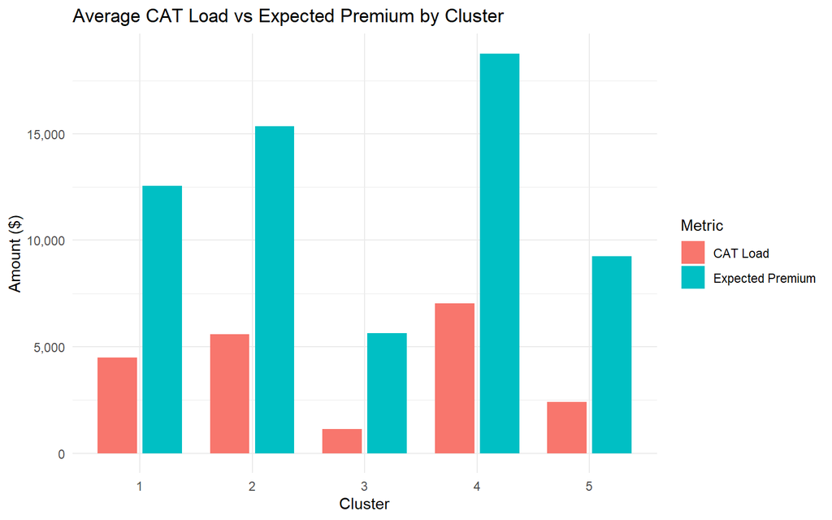

```r
ggplot(cluster_summary_long, aes(x = cluster, y = Amount, fill = Metric)) +
  geom_col(position = position_dodge(width = 0.8), width = 0.7) +
  scale_y_continuous(labels = scales::comma) +
  labs(title = "Average CAT Load vs Expected Premium by Cluster",
       x = "Cluster", y = "Amount ($)", fill = "Metric") +
  theme_minimal()
```

# Plot 2: Total CAT Load by Cluster

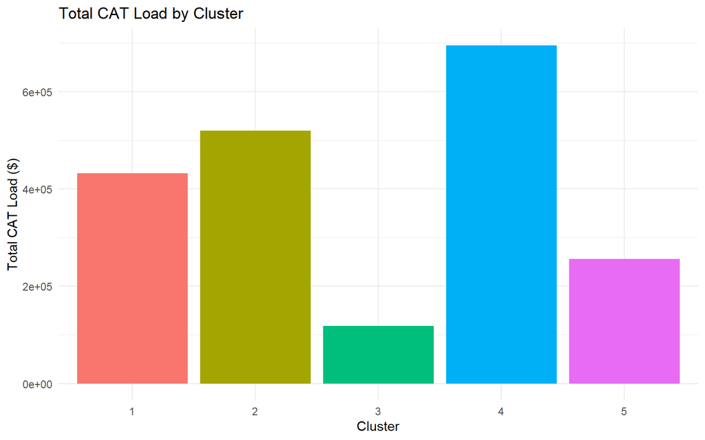

```r
ggplot(cluster_summary, aes(cluster, total_cat_load, fill = cluster)) +
  geom_col(show.legend = FALSE) +
  labs(title = "Total CAT Load by Cluster", x = "Cluster", y = "Total CAT Load ($)") +
  theme_minimal()
```

# Plot 3: Average Loss Ratio (CAT Load / Premium) by Cluster

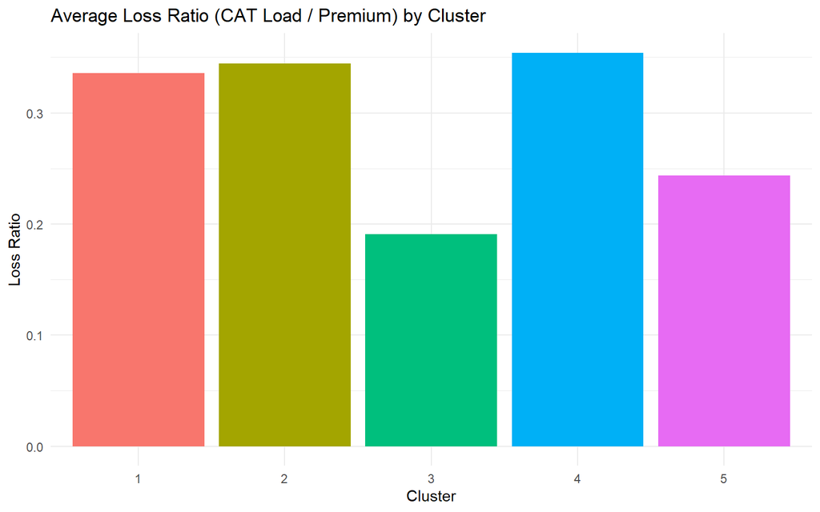

```r
ggplot(cluster_summary, aes(cluster, avg_loss_ratio, fill = cluster)) +
  geom_col(show.legend = FALSE) +
  labs(title = "Average Loss Ratio (CAT Load / Premium) by Cluster", x = "Cluster", y = "Loss Ratio") +
  theme_minimal()
```

## 6. EP curves, PML(100)/PML(200), TVaR(99/99.5)

```r
dt <- as.data.table(sim_matrix)
event_cluster_losses <- dt[, .(event_loss = sum(net_loss, na.rm=TRUE)),
                           by = .(cluster, event_id)]

metrics <- event_cluster_losses[, {
  m99  <- pml_tvar(event_loss, 0.99)
  m995 <- pml_tvar(event_loss, 0.995)
  .(PML_100 = m99$pml, TVaR_99 = m99$tvar,
    PML_200 = m995$pml, TVaR_99_5 = m995$tvar)
}, by = cluster]
```

```r
metrics %>%
  mutate(across(where(is.numeric), ~round(., 0))) %>%
  kable(caption = "PML & TVaR by Cluster") %>%
  kable_styling(bootstrap_options = c("striped","hover","condensed"), full_width = FALSE)
```

PML & TVaR by Cluster

| cluster | PML_100 | TVaR_99 | PML_200 | TVaR_99_5 |
| --- | --- | --- | --- | --- |
| 4 | 3736267 | 4412083 | 4021953 | 4984691 |
| 3 | 913354 | 1103013 | 993478 | 1263726 |
| 1 | 2498202 | 2960370 | 2693573 | 3351957 |
| 2 | 2882835 | 3408789 | 3105170 | 3854421 |
| 5 | 1618439 | 1928789 | 1749633 | 2191744 |

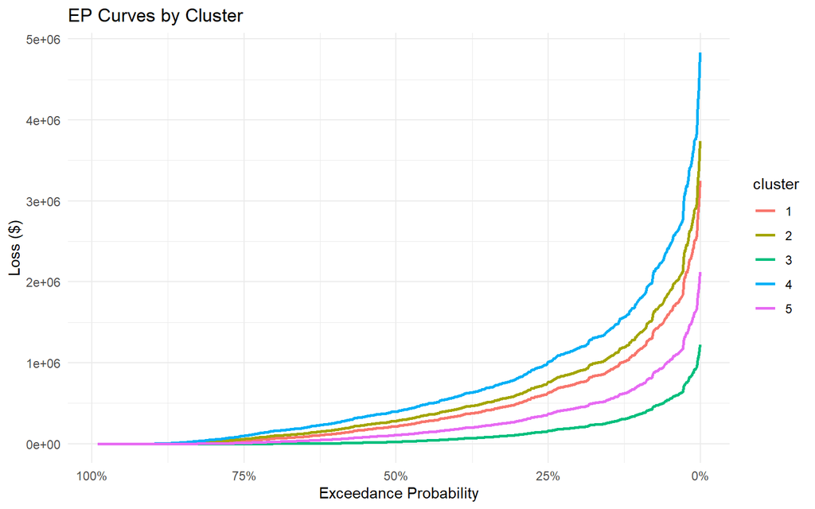

```r
probs <- seq(0.001, 0.99, by = 0.001)
ep <- event_cluster_losses[, .(
  loss = quantile(event_loss, probs = 1 - probs, na.rm = TRUE),
  ep   = probs
), by = cluster]

ggplot(ep, aes(ep, loss, color = cluster)) +
  geom_line(linewidth = 1.05) +
  scale_x_reverse(labels = scales::percent) +
  labs(title = "EP Curves by Cluster", x = "Exceedance Probability", y = "Loss ($)") +
  theme_minimal()
```

## 7. EP curves after hardening

## Portfolio-level EP curve overlay

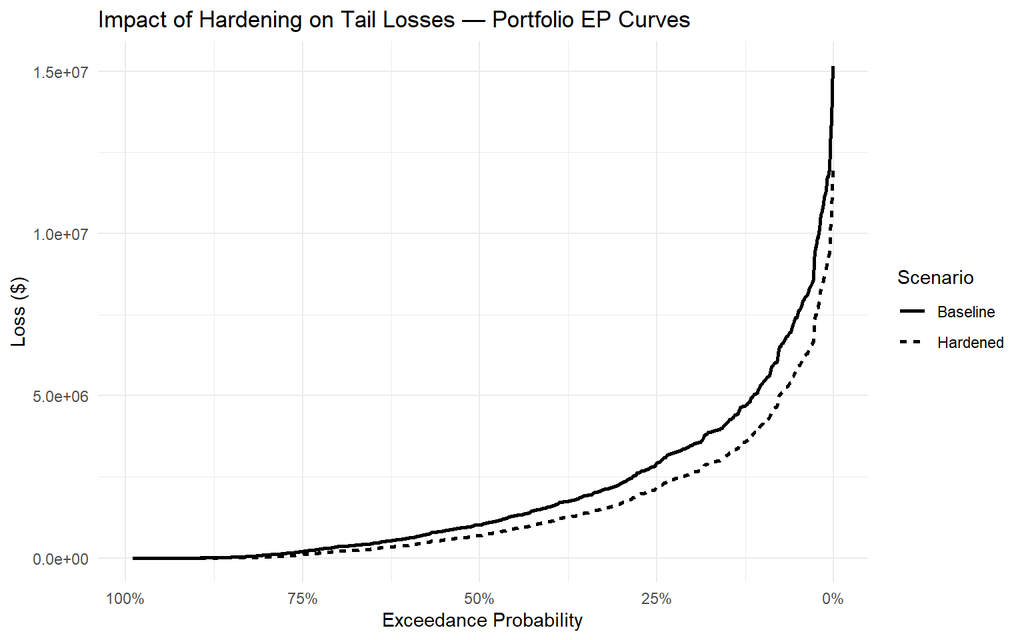

## Portfolio metrics before vs after

Portfolio Metrics — Before vs After Hardening

| Metric | Baseline | Hardened | Δ ($) | Δ (%) |
| --- | --- | --- | --- | --- |
| AAL | 2021343 | 1511344 | -509999 | -25.2% |
| PML(100) | 11649097 | 9141278 | -2507819 | -21.5% |
| TVaR(99) | 13813044 | 10872339 | -2940705 | -21.3% |
| PML(200) | 12563807 | 9873046 | -2690761 | -21.4% |
| TVaR(99.5) | 15646540 | 12339041 | -3307500 | -21.1% |

## Cluster-level AAL and tail benefits

Cluster-Level Benefits — AAL and Tail Metrics (Hardened minus Baseline)

| Cluster | AAL_Base | AAL_Hardened | dAAL | dPML100 | dTVaR99 |
| --- | --- | --- | --- | --- | --- |
| 4 | 7,022 | 5,353 | -1,668 | -783,253 | -918,417 |
| 2 | 5,591 | 4,219 | -1,371 | -609,567 | -714,758 |
| 1 | 4,499 | 3,353 | -1,147 | -535,640 | -628,074 |
| 5 | 2,392 | 1,739 | -653 | -359,688 | -421,758 |
| 3 | 1,127 | 771 | -356 | -219,671 | -257,698 |

## AAL savings by cluster bar chart

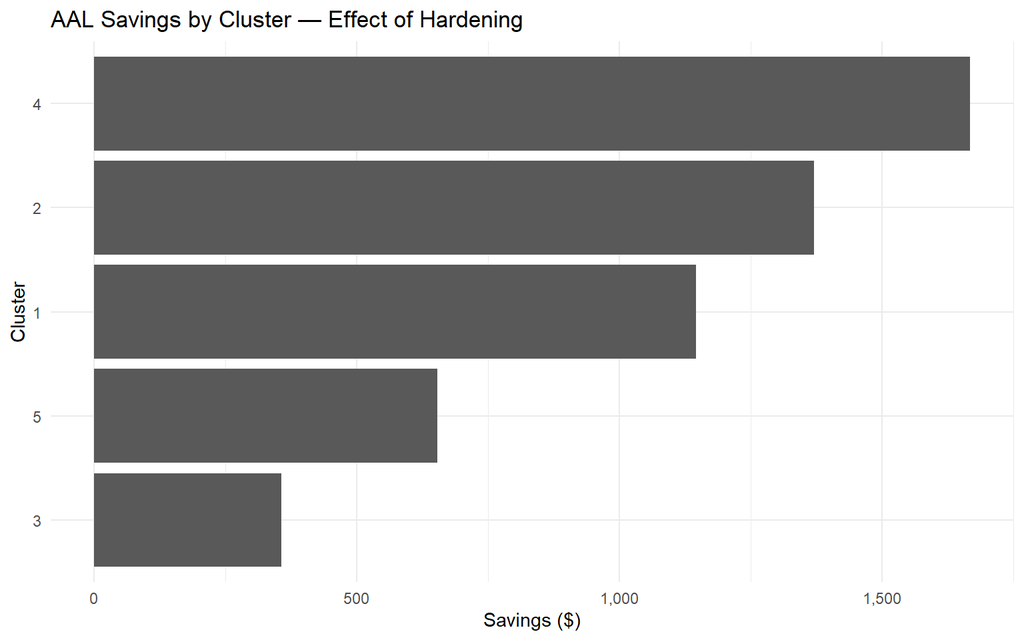

Pricing Adequacy by Cluster (CAT Load vs Premium)

| Cluster | Avg_CAT_Load | Avg_Premium | CAT_Load_to_Premium |
| --- | --- | --- | --- |
| 4 | 7,022 | 18,769 | 0.374 |
| 2 | 5,591 | 15,363 | 0.364 |
| 1 | 4,499 | 12,551 | 0.358 |
| 5 | 2,392 | 9,244 | 0.259 |
| 3 | 1,127 | 5,627 | 0.200 |

# Interpretation of Results

The results provide a structured view of how clustered exposures perform under simulated catastrophe shocks:

1. **Avg CAT Load vs Expected Premium (Plot 1)**
   - In every cluster, **Expected Premium > Avg CAT Load**.
   - That means the modeled catastrophe portion of loss is **covered by the current premium** on an average-year basis.
2. **Total CAT Load by Cluster (Plot 2)**
   - Cluster **4** contributes the **largest absolute CAT dollars** (portfolio accumulation).
   - Even with adequate average pricing, high dollar accumulation makes Cluster 4 the **dominant driver of portfolio volatility and tail risk**.
3. **Average Loss Ratio (Plot 3)**
   - CAT loss ratios (CAT Load / Premium) are **< 1.0** across the board.
   - Cluster 4, then 2 and 1, sit at the higher end of ratios; Cluster 3 is the lowest.
   - Interpretation: pricing **isn’t under** for CAT, but some clusters **consume more of the premium** to cover CAT risk, leaving less room for non-CAT perils, expenses, and margin.
4. **PML & TVaR Table**
   - Cluster **4** shows the **largest PML(100) and TVaR(99)** values → highest **extreme-event exposure**.
   - TVaR being meaningfully above PML confirms a **fat tail**; this is where reinsurance and capital decisions bite.
5. **EP Curves**
   - Cluster 4’s curve sits **highest/right-most** in the tail → at the same exceedance probability, it expects **bigger losses** than other clusters.
   - Clusters 1 and 2 follow; Cluster 3 is most resilient.

## Actionable Takeaways

- **Risk transfer & capital:** Size reinsurance layers primarily off **Cluster 4** (tail-heavy), then 2 and 1. Use PML/TVaR to set attachment and limits.
- **Portfolio steering:** If you want to reduce tail, **de-risk Cluster 4** (blend of underwriting appetite, limits, and accumulation caps).
- **Resilience capex:** Prioritize hardening for assets in Cluster 4 (and next 2/1). Even if pricing covers average CAT, **tail losses** dominate capital and rating-agency views.
- **Pricing adequacy (CAT slice only):** Current premium covers modeled CAT across clusters. Any overall pricing action should consider **non-CAT perils + expenses + target margin** on top of the CAT slice.

*Bottom line:* CAT pricing looks **adequate on average**, but **tail concentration** (PML/TVaR, EP curves) makes **Cluster 4** the lever for reinsurance, capital efficiency, and resilience ROI.